# Onlineko idazkuntza prozesua aztertzeko: IDAT

Juan Abasolo

Naia Eguskiza

Aintzane Etxebarria

XXVII. Psikodidaktika Jardunaldiak 2020-11-24

### Oinarritzea

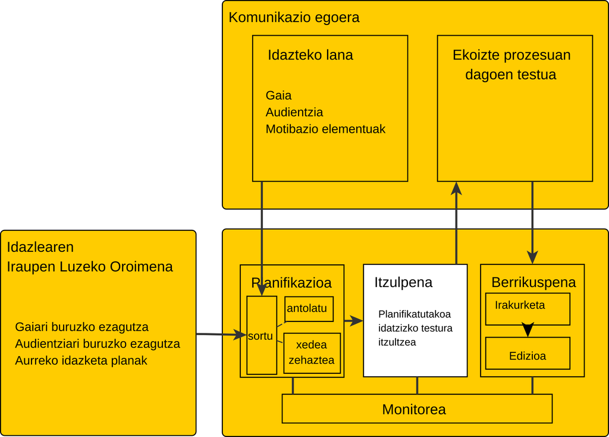

Hizkuntza idatziaren (denbora) ezaugarriak: “Structure of the Writing Model”-en itzulpena, Hayes & Flower, 1980:208

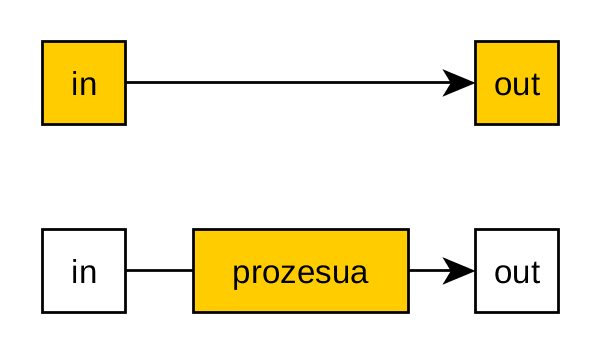

Idazketaren ikerketa

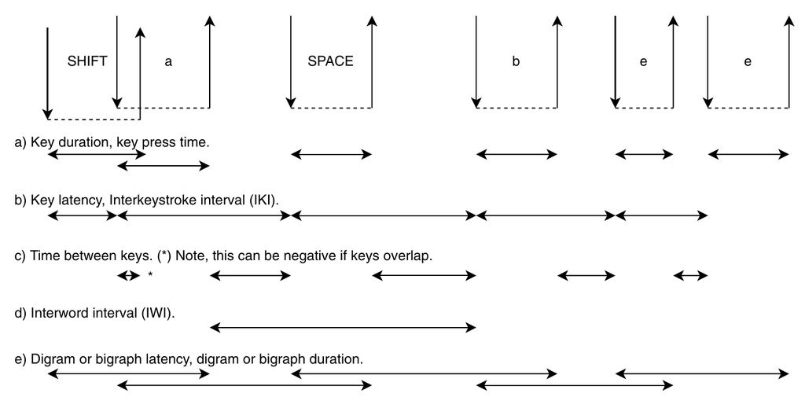

Prozesuaren grabaketa:“A bee”, Conijin et al. (2019)

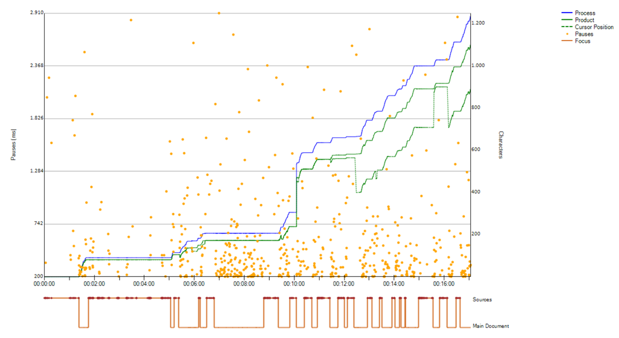

InputLog

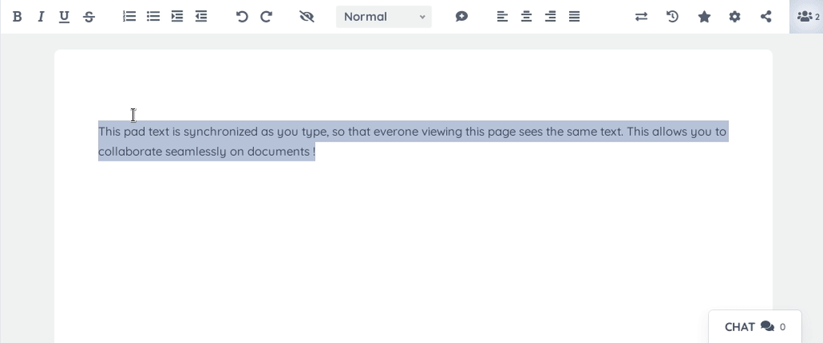

Etherpad

[figure not shown]

R

# Helburua

### Metodologia

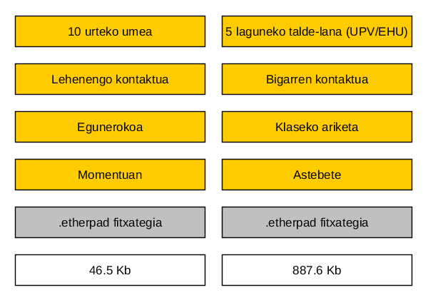

Lagina

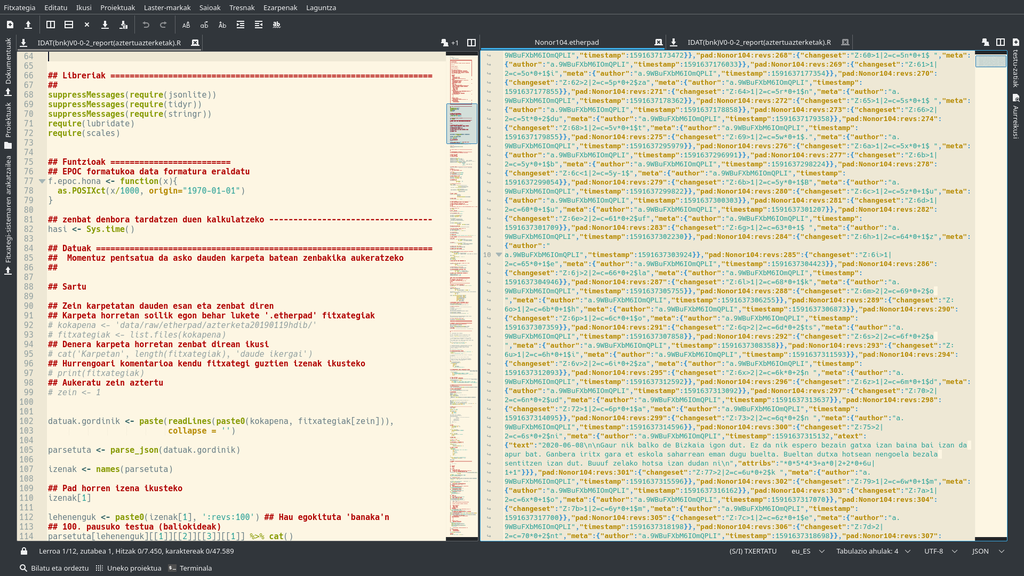

Etherpad eta IDAT

### Emaitzak

Denbora ezaugarriak

| Inputlog-eko txosteneko elementuak | IDAT banaka | IDAT taldean | oharrak |
| --- | --- | --- | --- |
| Prozesuaren iraupena | 8.42 min | 1.84 egun |  |
| Etenak denera | 35 seg | 6.28 min | 3 seg eta 20 seg artean |
| Aktiboki idazketan jardundako denbora | 5.13 min | 27.55 min | 20 seg baino gutxiagoko etenekin |
| Pentsatzen ala idazten jardundako proportzioa | 0.11 | 0.22 |  |

Prozesua

| Inputlog-eko txosteneko elementuak | IDAT banaka | IDAT taldean | oharrak |
| --- | --- | --- | --- |
| Zenbat berba eta zenbat karaktere (idatzi diren prozesuan eta gelditu diren testuan) | - | - | Berbak ez dira kontatu |
| Abiadura (karaktereak minutuko, prozesuaren arabera) | 64.56/86.60 | 81.84/240.94 | Testuan/Prozesuan |
| Produktu/Prozesuaren ratioa | 0.74 | 0.33 |  |

Jokabidea etenaldietan

| Inputlog-eko txosteneko elementuak | IDAT banaka | IDAT taldean | oharrak |
| --- | --- | --- | --- |
| Kopurua | 11 | 103 |  |
| Batezbestekoaren iraupena | 6seg/3.7seg | 6.62seg/3.44seg | Batezbestekoa eta desbiderapen estandarra |
| Etenen bitarteko testuen luzeraren batezbestekoa eta desbierapen estandarra | - | - |  |
| Etenen bitarteko idatzi aldikoen luzapenaren batezbestekoa eta desbiderapen estandarra | - | - |  |

Berrikuspenerako jokaera

| Inputlog-eko txosteneko elementuak | IDAT banaka | IDAT taldean | oharrak |
| --- | --- | --- | --- |
| Berrikuspen kopurua (ezabatzeak eta txertaketak) | 42 | 310 |  |
| Berrikuspenen batezbestekoa 100 berbako | 80.76 | 106 |  |
| Berrikuspenen batezbestekoa minutuko | 7.34 | 9 |  |
| Berrikuspenen luzeraren erdiko balioa |  |  |  |

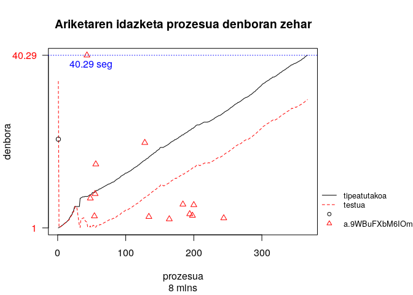

Ume baten jardun idatzia

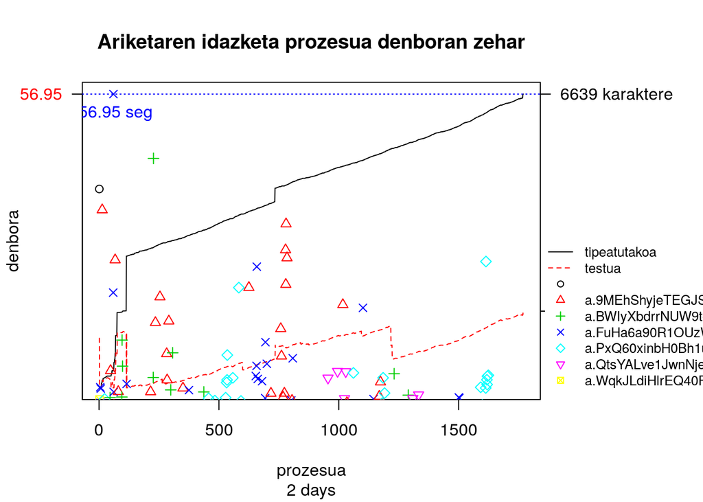

Talde baten jardun idatzia

### Ondorioak eta gerokoak

## Helburuen ikuskeratik

## Garapena

- Testualitatearen berreskurapena
- Erabilera didaktikoak
- Tresna pedagogikoa

### erreferentziak

Abasolo, J., Unamuno, L., & de Pablo, I. (2018, azaroak 20). *Idazketa aztertzeko tresna*. XXV. psikodidaktika jardunaldiak / XXV Jornadas de Psicodidáctica, Vitoria-Gasteiz.

Conijn, R., Roeser, J., & van Zaanen, M. (2019). Understanding the keystroke log: The effect of writing task on keystroke features. *Reading and Writing*, *32*(9), 2353–2374. https://doi.org/10/ggjr78

Flower, L., & Hayes, J. R. (1981). A Cognitive Process Theory of Writing. *College Composition and Communication*, *32*(4), 365. https://doi.org/10/bn59g4

Greenspan, D., Iba, A., & Zamfirescu, J. D. (2008). *Etherpad: Really real-time collaborative document editing* (1.7) [JavaScript]. Etherpad. http://etherpad.org

Hayes, J. R., & Flower, L. (1980). Identifying the organization of writing processes. *Cognitive processes in Writing*. https://ci.nii.ac.jp/naid/10010327319/

Ihaka, R., & Gentleman, R. (1996). R: A Language for Data Analysis and Graphics. *Journal of Computational and Graphical Statistics*, *5*(3), 299–314. https://doi.org/10/gddc3n

Kollberg, P., Kim, H.-C., & Severinson-Eklundh, K. (1996). Trace-it: An interactive tool for revision analysis. *European writing conferences barcelona, spain*, 23–25.

Leijten, M., & Van Waes, L. (2005). *Inputlog: A logging tool for the research of writing processes*. 22.

Leijten, M., & Van Waes, L. (2013). Keystroke Logging in Writing Research: Using Inputlog to Analyze and Visualize Writing Processes. *Written Communication*, *30*(3), 358–392. https://doi.org/10/f5q5cm

Matsuhashi, A. (1981). Pausing and Planning: The Tempo of Written Discourse Production. *Research in the Teaching of English*, *15*(2), 113–134.

Severinson-Eklundh, K., & Kollberg, P. (1992). Translating keystroke records into a general notation for the writing process (IPLab-59). *Stockholm: Department of Numerical Analysis and Computing Science, Royal Institute of Technology*.

# Idazkuntza Aztertzeko Tresna: IDAT

juan.abasolo@ehu.eus

naia.egusquiza@ehu.eus

aintzane.etxebarria@ehu.eus